# Seminar 1

Sören Twietmeyer

2023-10-18

#### Instruction:

1. Create a R Markdown document
2. Follow [this link](https://www.markdownguide.org/basic-syntax/) for help with basic R syntax OR copy and past this URL in your browser: https://www.markdownguide.org/basic-syntax/
3. Follow [this link](https://markdownguide.offshoot.io/extended-syntax/#automatic-url-linking) to help with extended R syntax OR copy and past this URL in your browser: https://markdownguide.offshoot.io/extended-syntax/#automatic-url-linking
4. Answer all questions.
5. Write out each question and provide the solution immediately after using a title “**Answer**”.
   - You can copy the question directly from this document.
   - Be sure to provide an explanation of your code where relevant.
6. Upload your Markdown file to your GitHub account.
7. Provide the link to the GitHub document
8. Convert your output to a PDF document and submit on Moodle.

Complete the following:

> 1. Write your name and surname in bold font, with your Name ONLY in italics.

**Sören** *Twietmeyer*

> 2. Print your student number and what year you are in on different lines.

```
Answer Below
```

```r
print("u238790")
```

```
## [1] "u238790"
```

> 3. Briefly state, in italics, why you are doing this Data Science Module

```
Answer Below
```

*I hope it was going to be a good addition to learn*

> 4. Make an unordered list of at least 3 things you have learned in this module.

[output not shown]

```
Answer Below
```

```r
#table(c("A, B, C, D, E"), c(1, 2, 3, 4, 5))
```

| S/N | Name | Surname |
| --- | --- | --- |
| 1. | Tom | Hardy |
| 2. | Tom | Cruise |

this is not really good looking

> 6. Create an ordered list of at least 3 other Data Science methodologies.

[output not shown]

> 7. Provide and ordered list the weaknesses of the CRISP-DM methodology and how to address them

[output not shown]

> 8. Download and include a University of Warwick Logo in your document.

[output not shown]

> 9. Write and execute a code to randomly generate 10 numbers from a normal distribution with mean 12 and standard deviation 3.

[output not shown]

> 10. Write and execute a code to calculate the mean of 12 random numbers generated from the intervalof integes from 5 to 25.

[output not shown]

> 11. Write and execute a code to create a scatter plot containing 12 points whose coordinates were randomly geenrated in the interval 5 to 25. Provide a title for the figure, label the x and y axis.

[output not shown]

> 12. Write and execute a code to create a function to calculate standard error. Then, calculate the standard error of a set of 15 randomly generated numbers from a normal distribution with mean 12 and standard deviation 3.

[output not shown]

> 13. Given that BMI=kg/m2, where kg is the person’s weight in kilograms and m2is height in meters squared, write and execute a code to create a function that calculates the BMI of who weighs 85kg and is 1.9m tall.

[output not shown]

```r
mtcars$disp
```

```
##  [1] 160.0 160.0 108.0 258.0 360.0 225.0 360.0 146.7 140.8 167.6 167.6 275.8
## [13] 275.8 275.8 472.0 460.0 440.0  78.7  75.7  71.1 120.1 318.0 304.0 350.0
## [25] 400.0  79.0 120.3  95.1 351.0 145.0 301.0 121.0
```

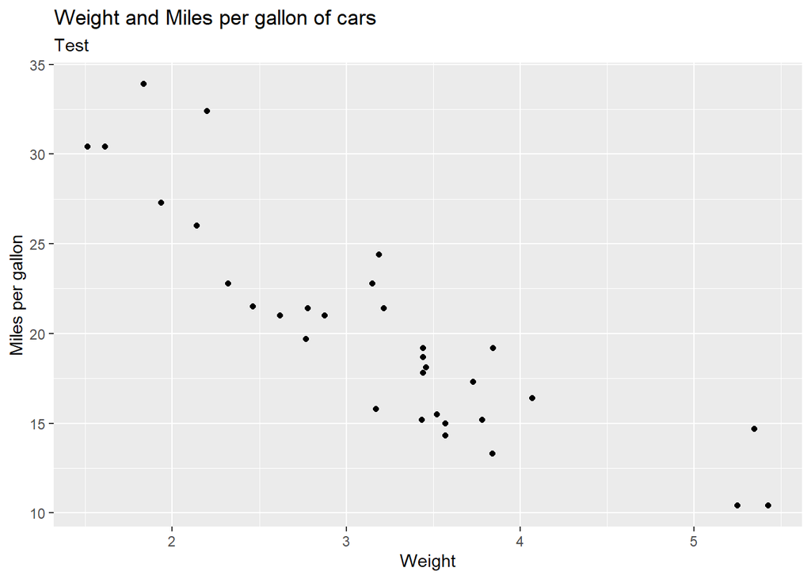

```r
test_tibble <- as_tibble(mtcars)
test_tibble <- test_tibble %>% rename("weight" = "wt")
ggplot(mtcars, aes(wt, mpg)) + geom_point() + xlab("Weight") + ylab("Miles per gallon") + ggtitle("Weight and Miles per gallon of cars", subtitle = "Test")
```